# CYO-OTI Class Recommender

Robert Lewis

June 13, 2019

### Final Project Introduction

# The purpose of this project (CYO) is to create an algorithm for recommending classes for users based on other programs they have completed and the scores they received. I will be using a subset of modified data to protect the actual users infomation. I will use the recommenderlab for making my recommendation and use different models to identify the best model with the lowest error acuracy.

```r
if(!require(dplyr)) install.packages("dplyr", repos = "http://cran.us.r-project.org")
if(!require(stringr)) install.packages("stringr", repos = "http://cran.us.r-project.org")
if(!require(tidyverse)) install.packages("tidyverse", repos = "http://cran.us.r-project.org")
if(!require(caret)) install.packages("caret", repos = "http://cran.us.r-project.org")
if(!require(data.table)) install.packages("data.table", repos = "http://cran.us.r-project.org")
if(!require(useful)) install.packages("useful", repos = "http://cran.us.r-project.org")
if(!require(lubridate)) install.packages("lubridate", repos = "http://cran.us.r-project.org")
if(!require(recommenderlab)) install.packages("recommenderlab", repos = "http://cran.us.r-project.org")
library(dplyr)
library(stringr)
library(tidyverse)
library(caret)
library(data.table)
library(useful)
library(lubridate)
library(recommenderlab)
```

# Initial data variables

# Get lastest data available from OSHA

```r
if(!file.exists("OnlineStudentHistory.csv")){
    download.file("https://github.com/Roberttheachiever/OTIMarketing/OnlineStudentHistory.csv", destfile = "OnlineStudentHistory.csv")}

Student_data <- read.csv(file.path("OnlineStudentHistory.csv"))
```

# Review structure and details of dataset

```r
nrow(Student_data) #courses taking by students
```

```
## [1] 58483
```

```r
ncol(Student_data)  #data columns
```

```
## [1] 4
```

```r
names(Student_data) #column Names
```

```
## [1] "StudentID"  "CourseID"   "CourseName" "Rating"
```

```r
str(Student_data)  #structure of data
```

```
## 'data.frame':    58483 obs. of  4 variables:
##  $ StudentID : int  50000 50000 50000 50001 50001 50001 50003 50004 50005 50007 ...
##  $ CourseID  : int  168 66 84 166 168 88 5 166 165 165 ...
##  $ CourseName: Factor w/ 38 levels "10 Hour Construction Industry",..: 4 8 33 2 4 14 13 2 1 1 ...
##  $ Rating    : num  88 70 73 73 90.5 72 84.5 76 95 71 ...
```

```r
summary(Student_data) #stats per columns
```

```
##    StudentID        CourseID
##  Min.   :50000   Min.   :  5.0
##  1st Qu.:62491   1st Qu.: 83.0
##  Median :75036   Median :165.0
##  Mean   :75038   Mean   :128.8
##  3rd Qu.:87576   3rd Qu.:166.0
##  Max.   :99999   Max.   :168.0
##
##                                              CourseName        Rating
##  10 Hour Construction Industry                    :17929   Min.   :70.00
##  10 Hour General Industry                         : 8387   1st Qu.:77.00
##  30 Hour Construction Industry                    : 8055   Median :84.50
##  Hazardous Waste Operations and Emergency Response: 4567   Mean   :84.51
##  OSHA Fall Protection Course                      : 3140   3rd Qu.:92.00
##  30 Hour  General Industry                        : 3092   Max.   :99.00
##  (Other)                                          :13313
```

```r
class(Student_data) #dat.frame
```

```
## [1] "data.frame"
```

```r
unique_studentIds<-unique(Student_data$StudentID) # get unique Student IDS

students <- sample(unique(Student_data$StudentID),100) # get small sample of data to explore

student_matrix <- Student_data %>%
  select(StudentID,CourseID,Rating) %>%
  mutate(Rating = 1) %>%
  spread(CourseID, Rating) %>%
  as.matrix()

cat("Sample of Student Data\n\n")
```

```
## Sample of Student Data
```

```r
corner(student_matrix, c=12,r=12) #view data
```

```
##       StudentID  5  6 48 65 66 68 69 71 72 73 74
##  [1,]     50000 NA NA NA NA  1 NA NA NA NA NA NA
##  [2,]     50001 NA NA NA NA NA NA NA NA NA NA NA
##  [3,]     50003  1 NA NA NA NA NA NA NA NA NA NA
##  [4,]     50004 NA NA NA NA NA NA NA NA NA NA NA
##  [5,]     50005 NA NA NA NA NA NA NA NA NA NA NA
##  [6,]     50007 NA NA NA NA NA NA NA NA NA NA NA
##  [7,]     50012 NA NA NA  1 NA NA NA NA NA NA NA
##  [8,]     50013 NA NA NA NA NA NA NA NA NA NA NA
##  [9,]     50014 NA NA NA NA NA NA NA NA NA NA NA
## [10,]     50015 NA NA NA NA NA NA NA NA NA NA NA
## [11,]     50016 NA NA NA NA  1 NA NA NA NA NA NA
## [12,]     50017 NA NA NA NA NA NA NA NA NA NA  1
```

*Note:*

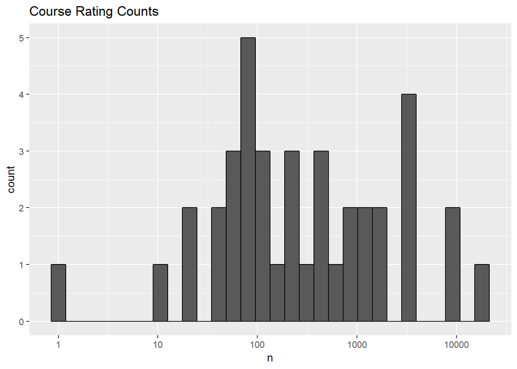

```r
#Plot Course Rating Counts for the count of courses rated:
Student_data %>%
  dplyr::count(CourseID) %>%
  ggplot(aes(n)) +
  geom_histogram(bins = 30, color = "black") +
  scale_x_log10() +
  ggtitle("Course Rating Counts")
```

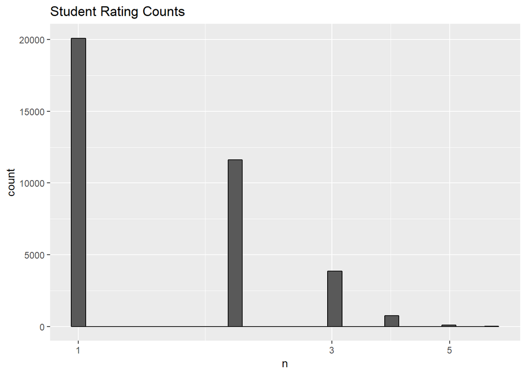

```r
#Plot StudentData for the count of Student ratings:
Student_data %>%
  dplyr::count(StudentID) %>%
  ggplot(aes(n)) +
  geom_histogram(bins = 30, color = "black") +
  scale_x_log10() +
  ggtitle("Student Rating Counts")
```

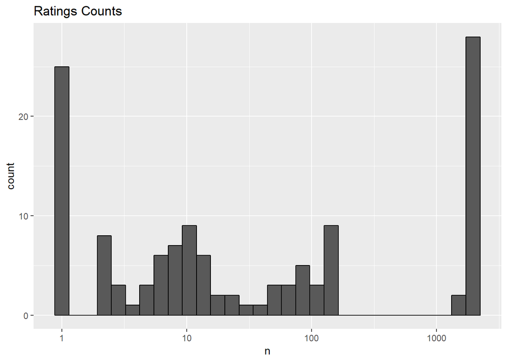

```r
#Plot StudentData for the count of ratings:

Student_data %>%
  dplyr::count(Rating) %>%
  ggplot(aes(n)) +
  geom_histogram(bins = 30, color = "black") +
  scale_x_log10() +
  ggtitle("Ratings Counts")
```

### Preparing Data:

#### Convert to realRatingMatrix

```r
Students_2 <- dcast(StudentID ~ CourseID, data = Student_data1, value.var = "Rating")
dim(Students_2)
```

```
## [1] 16332    39
```

```r
class(Students_2)
```

```
## [1] "data.frame"
```

```r
#view data
require(useful)
corner(Students_2)
```

```
##   StudentID  5  6 65 66
## 1     50000 NA NA NA 70
## 2     50001 NA NA NA NA
## 3     50007 NA NA NA NA
## 4     50012 NA NA 83 NA
## 5     50014 NA NA NA NA
```

```r
#change rownames
rownames(Students_2) <- sprintf("Student_%s",Students_2$StudentID)
Students_2$StudentID <- NULL
corner(Students_2)
```

```
##                5  6 65 66 68
## Student_50000 NA NA NA 70 NA
## Student_50001 NA NA NA NA NA
## Student_50007 NA NA NA NA NA
## Student_50012 NA NA 83 NA NA
## Student_50014 NA NA NA NA NA
```

```r
#change column Names
colnames(Students_2) <- sprintf("Course_%s",colnames(Students_2))
corner(Students_2)
```

```
##               Course_5 Course_6 Course_65 Course_66 Course_68
## Student_50000       NA       NA        NA        70        NA
## Student_50001       NA       NA        NA        NA        NA
## Student_50007       NA       NA        NA        NA        NA
## Student_50012       NA       NA        83        NA        NA
## Student_50014       NA       NA        NA        NA        NA
```

```r
#convert to matrix
Students_2 <- as.matrix(Students_2)
dim(Students_2)
```

```
## [1] 16332    38
```

```r
class(Students_2)
```

```
## [1] "matrix"
```

```r
#convert to realRatingMatrix
Students_3 <- as(Students_2 , "realRatingMatrix")
class(Students_3)
```

```
## [1] "realRatingMatrix"
## attr(,"package")
## [1] "recommenderlab"
```

```r
str(Students_3)
```

```
## Formal class 'realRatingMatrix' [package "recommenderlab"] with 2 slots
##   ..@ data     :Formal class 'dgCMatrix' [package "Matrix"] with 6 slots
##   .. .. ..@ i       : int [1:38379] 8 23 24 31 50 56 61 67 68 77 ...
##   .. .. ..@ p       : int [1:39] 0 2117 3343 4091 6576 6634 6643 6686 6703 6748 ...
##   .. .. ..@ Dim     : int [1:2] 16332 38
##   .. .. ..@ Dimnames:List of 2
##   .. .. .. ..$ : chr [1:16332] "Student_50000" "Student_50001" "Student_50007" "Student_50012" ...
##   .. .. .. ..$ : chr [1:38] "Course_5" "Course_6" "Course_65" "Course_66" ...
##   .. .. ..@ x       : num [1:38379] 70 90 72 82 77 95 73 70 87 80 ...
##   .. .. ..@ factors : list()
##   ..@ normalize: NULL
```

#### Review the prepared dataset

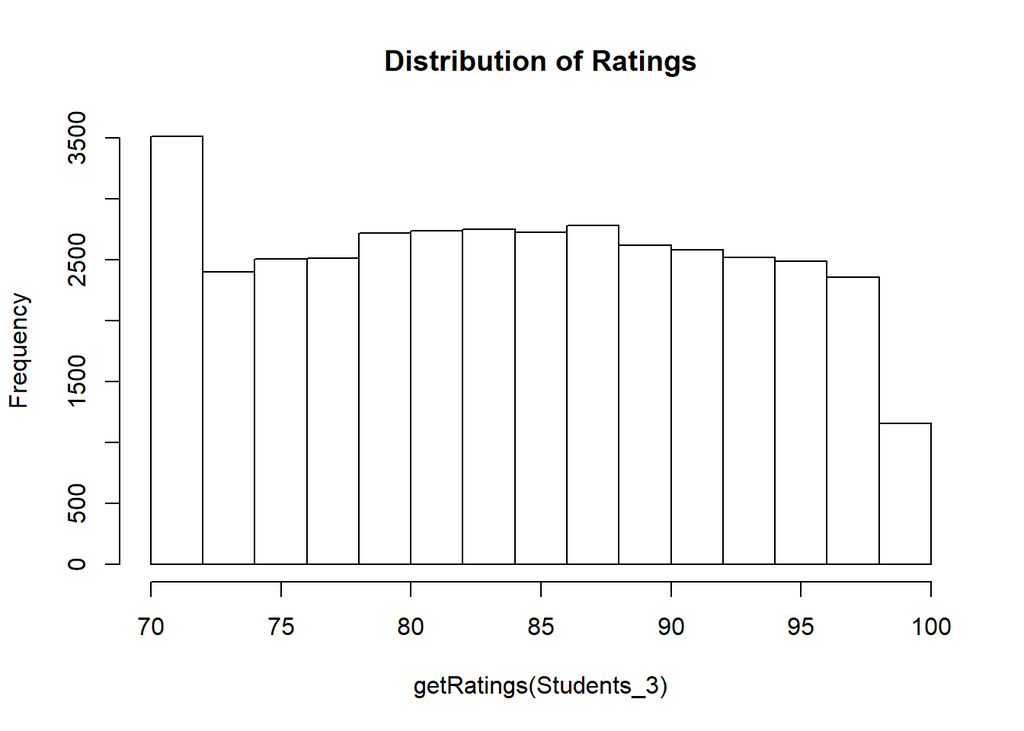

```r
#Review ratings distribution
hist(getRatings(Students_3), main = "Distribution of Ratings")
```

# The Distribution of Ratings shows we have different possible ratings from 70 to 100

This data is based on the students who completed courses which reqires 70% which is apparent looking at the data.

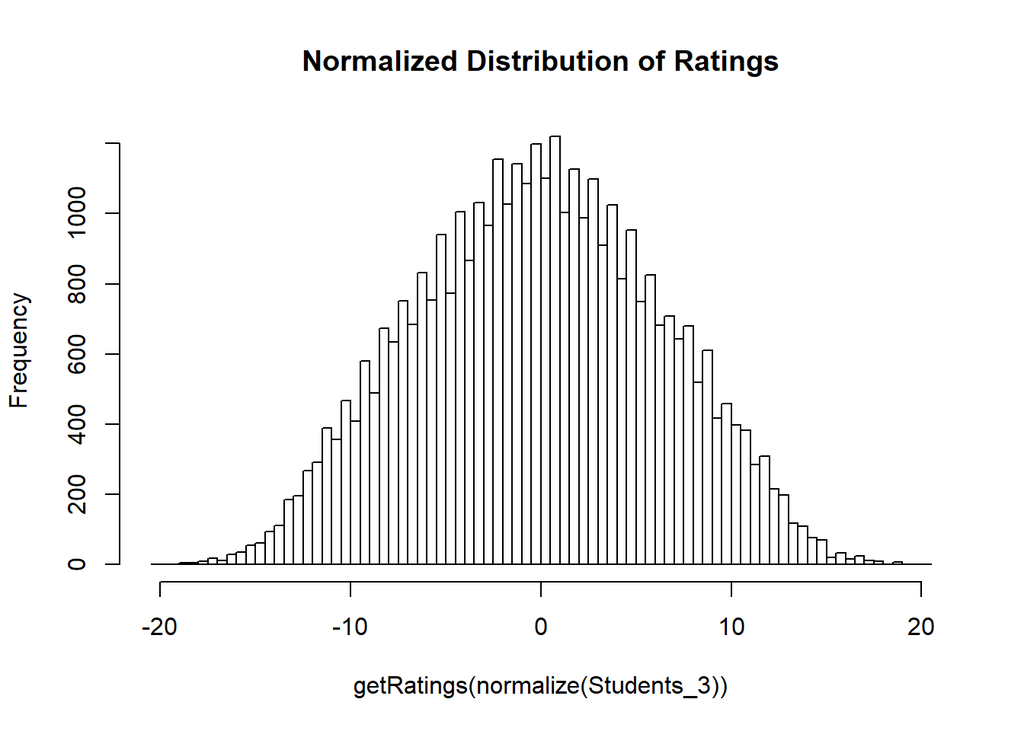

*Data appears to be normalized*

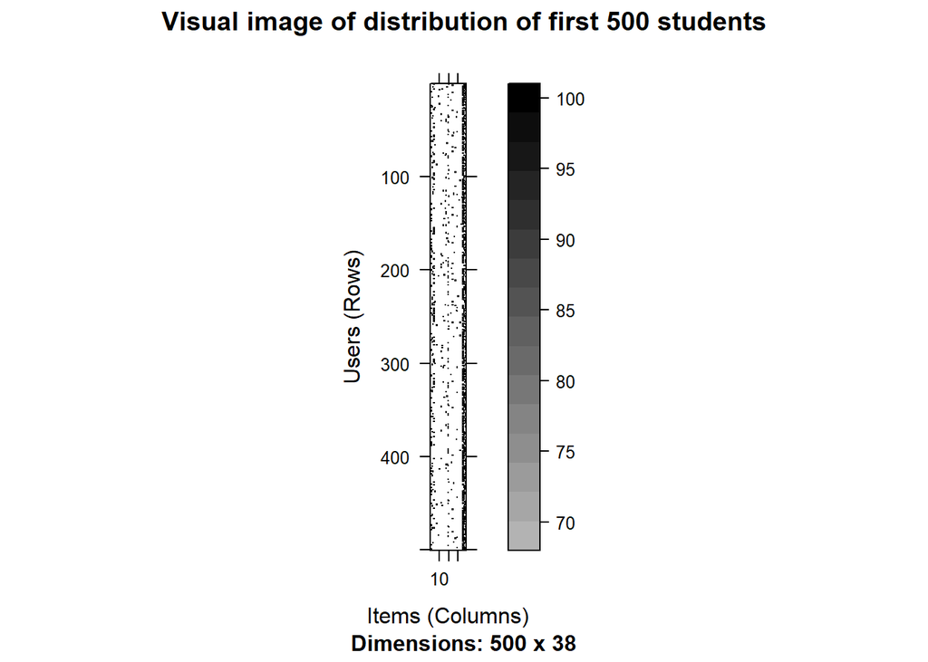

````r
##```{r Visual image of distribution of first 500 users, echo=FALSE}
image(Students_3[1:500,],main = "Visual image of distribution of first 500 students")
````

*It appears the scores are evenly disriputed*

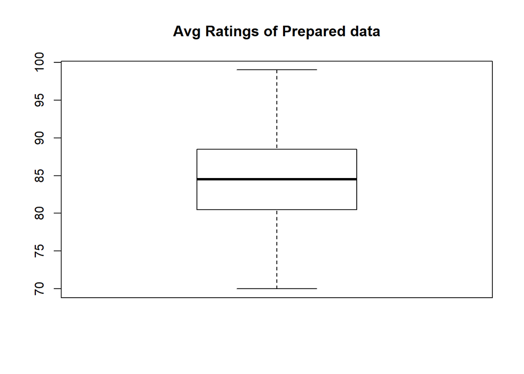

````r
##```{r Avg Ratings of Prepared data, eval=FALSE, include=FALSE}
boxplot(rowMeans(Students_3),main = "Avg Ratings of Prepared data")
````

*No outliers appear to be found that may skew the results*

```r
model_data = Students_3
#Create model data, echo=FALSE, message=FALSE, warning=FALSE, paged.print=FALSE}
dim(model_data)
```

```
## [1] 16332    38
```

```r
#Number of Rating remaining in Model Data
nratings(model_data)
```

```
## [1] 38379
```

#### Model dataset Distribution of Ratings

# Plot the Model Data Course ratings

[figure not shown]

```r
hist(getRatings(model_data), main = "Distribution of Ratings after removing Outliers")
```

*Note rating are fair even with the exception of 70 which appear could be given by instructor to pass a student.*

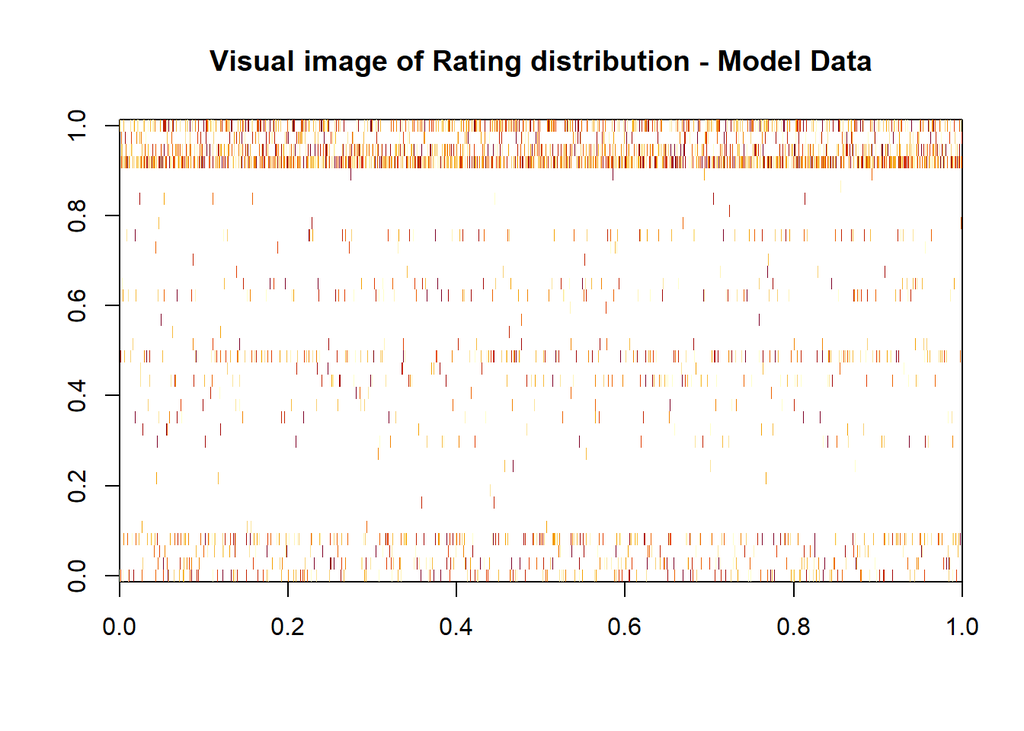

*Note Prepared Model ratings data appears slightly skewed.*